# QRM II Graded Assignment (9)

Period 1, 2026

Assignement Group 39: Jake Kody Te Koppele Blakey, Omer Faruk, Timo Crowther, Jaleel Bart & Fatima Malik

25-09-2026

# Introduction

This assignment is to be completed in groups of 4-5. Further, all students in your group need to be assigned to the same R tutorial group (Friday’s tutorial). You can sign yourself up for a group on Canvas. Please do so You can use the Discussion Board in Canvas if you do not have a group yet or if your group is incomplete.

The assignment has 5 parts, and each part corresponds to the course material of that week (with the exclusion of week 6, for which there is no R programming material).

You are supposed to hand in these assignments on Canvas at the following dates:

- **Deadline 1** *Sunday September 27th, at 23:59pm*: you are supposed to hand in weeks 1, 2, and 3 of this assignment. This will determine 18% of your overall course grade
- **Deadline 2** *Sunday October 11th, at 23:59pm*: you are supposed to hand in weeks 4, and 5 of this assignment. This will determine 12% of your overall course grade

The R tutorials (each Friday) will consist of two halves. During the first half, you will discuss the tutorial exercises. These can be downloaded separately from Canvas. During the second half, you can work on this graded assignment within your own group. The purpose is that you find out how to work with R for doing statistical analyses by yourself. The tutorial exercises are meant to teach you basic commands to get you started, but to answer the problem sets in this assignment, you might need to research your own solutions, and use functions and commands not described in the tutorial exercises. Learning how to solve your own research problems is integral part of learning R. When you and your group get stuck on how to approach an exercise, the hierarchy in finding your way is as follows:

- use the concepts from the tutorial exercises;
- use the cheat sheets available on Canvas;
- use Google, YouTube, StackOverflow, or another website;
- ask the teacher.

To answer the assignment, you can simply fill out this R markdown document. There are designated places which you can fill with R code. There are also designated spaces for you to answer each question. Often, the structure of an answer will be as follows. First, you type the R code in the designated box. This will show how you analyzed the data to get the answer to the question. Below the box for the R code, you will then summarize your answer to the question, i.e. what are the conclusions that you draw from the data analysis?

When handing in, you are supposed to submit this .Rmd file, and a knitted version of this document. You can knit this document to pdf, word, or html. Knitting to pdf requires you to have a .tex distribution installed on your computer. Knitting to Word requires you to have Word installed.

The exercises are designed such that you should be able to finish the majority of them during the tutorial each week. If you are not able to finish them fully during that time, you are expected to work on it in your own time using the computers on campus or your own device. It is best to meet as a group in-person when working together. If you want to work remotely, github is a good platform to guarantee smooth collaboration. Alternatively, you can email this .Rmd file back and forth to one another as a group, but this is not recommended as it is more cumbersome.

We encourage you to keep your code blocks, printing statements, and final answers, as short as possible. In any case, there is a page limit of 6 pages per week, which encompasses the total length of this document which consists of the questions, your coding lines, and your answers. When your answers to questions of the respective week exceed this page limit, they will not be graded, resulting in zero points.

# Week 1

1. Find the dataset “movies3.tsv” on Canvas. Describe your data set: How many observations does it have. How many variables are there? How many subjects? What consists of a subject?

```r
#WRITE YOUR CODE HERE
dataset = read.delim("data/movies3.tsv")
library(tidyverse)
library(dplyr)
nrow(dataset)
```

```
## [1] 707
```

```r
ncol(dataset)
```

```
## [1] 19
```

```r
head(dataset)
```

|  | index | budget | keywords | original_language | title | popularity | release_date | revenue | runtime | vote_average | vote_count | genre | release_year | release_month | release_day | first_actor | first_actor_gender | director_first_name | director_gender |
| --- | --- | --- | --- | --- | --- | --- | --- | --- | --- | --- | --- | --- | --- | --- | --- | --- | --- | --- | --- |
| 1 | 2 | 2.45e+08 | spy based on novel secret agent sequel mi6 | en | Spectre | 107.376788 | 2015-10-26 | 880674609 | 148 | 6.3 | 4466 | Action | 2015 | 10 | 26 | Daniel Craig | male | Sam | male |
| 2 | 2460 | 1.60e+07 | NA | en | The Unborn | 15.788784 | 2009-01-09 | 76514050 | 87 | 4.8 | 365 | Thriller | 2009 | 1 | 9 | Odette Annable | female | David | male |
| 3 | 219 | 1.20e+08 | robbery secret identity secret agent | en | Charlie's Angels: Full Throttle | 33.616115 | 2003-06-27 | 259175788 | 106 | 5.2 | 914 | Comedy | 2003 | 6 | 27 | Cameron Diaz | male | McG | NA |
| 4 | 2900 | 1.20e+07 | NA | ja | Space Battleship Yamato | 5.158067 | 2010-12-01 | 11212294 | 131 | 6.3 | 59 | Fiction | 2010 | 12 | 1 | Hiroyuki Ikeuchi | male | Takashi | male |
| 5 | 2236 | 0.00e+00 | wave surfing sport mentor prot\\u00e9g\\u00e9 relationship santa cruz california | en | Chasing Mavericks | 13.621201 | 2012-10-25 | 0 | 117 | 7.0 | 216 | Drama | 2012 | 10 | 25 | Gerard Butler | male | Curtis | male |
| 6 | 386 | 7.50e+07 | berlin assassin based on novel amnesia sniper | en | The Bourne Supremacy | 53.213931 | 2004-07-23 | 288500217 | 108 | 7.2 | 2825 | Drama | 2004 | 7 | 23 | Matt Damon | male | Paul | male |

**Your Answer:**

The dataset has 707 observations and 19 variables, there are 707 subjects in the dataset and each subject is one movie, with each row representing one movie.

2. Which of the following types of variables are present in your data set? (i) nominal; (ii) ordinal; (iii); continuous; (iv) discrete. If present, name one example of such a variable present in your data set.

```r
#WRITE YOUR CODE HERE
str(dataset)
```

```
## 'data.frame':    707 obs. of  19 variables:
##  $ index              : int  2 2460 219 2900 2236 386 122 4627 1699 4636 ...
##  $ budget             : num  2.45e+08 1.60e+07 1.20e+08 1.20e+07 0.00 7.50e+07 1.50e+08 0.00 6.00e+07 0.00 ...
##  $ keywords           : chr  "spy based on novel secret agent sequel mi6" NA "robbery secret identity secret agent" NA ...
##  $ original_language  : chr  "en" "en" "en" "ja" ...
##  $ title              : chr  "Spectre" "The Unborn" "Charlie's Angels: Full Throttle" "Space Battleship Yamato" ...
##  $ popularity         : num  107.38 15.79 33.62 5.16 13.62 ...
##  $ release_date       : chr  "2015-10-26" "2009-01-09" "2003-06-27" "2010-12-01" ...
##  $ revenue            : num  8.81e+08 7.65e+07 2.59e+08 1.12e+07 0.00 ...
##  $ runtime            : int  148 87 106 131 117 108 107 99 104 96 ...
##  $ vote_average       : num  6.3 4.8 5.2 6.3 7 7.2 6.2 6.2 6.1 5.7 ...
##  $ vote_count         : int  4466 365 914 59 216 2825 4021 11 400 16 ...
##  $ genre              : chr  "Action" "Thriller" "Comedy" "Fiction" ...
##  $ release_year       : int  2015 2009 2003 2010 2012 2004 2009 2015 2001 2000 ...
##  $ release_month      : int  10 1 6 12 10 7 4 2 4 1 ...
##  $ release_day        : int  26 9 27 1 25 23 28 7 6 21 ...
##  $ first_actor        : chr  "Daniel Craig" "Odette Annable" "Cameron Diaz" "Hiroyuki Ikeuchi" ...
##  $ first_actor_gender : chr  "male" "female" "male" "male" ...
##  $ director_first_name: chr  "Sam" "David" "McG" "Takashi" ...
##  $ director_gender    : chr  "male" "male" NA "male" ...
```

```r
head(dataset)
```

|  | index | budget | keywords | original_language | title | popularity | release_date | revenue | runtime | vote_average | vote_count | genre | release_year | release_month | release_day | first_actor | first_actor_gender | director_first_name | director_gender |
| --- | --- | --- | --- | --- | --- | --- | --- | --- | --- | --- | --- | --- | --- | --- | --- | --- | --- | --- | --- |
| 1 | 2 | 2.45e+08 | spy based on novel secret agent sequel mi6 | en | Spectre | 107.376788 | 2015-10-26 | 880674609 | 148 | 6.3 | 4466 | Action | 2015 | 10 | 26 | Daniel Craig | male | Sam | male |
| 2 | 2460 | 1.60e+07 | NA | en | The Unborn | 15.788784 | 2009-01-09 | 76514050 | 87 | 4.8 | 365 | Thriller | 2009 | 1 | 9 | Odette Annable | female | David | male |
| 3 | 219 | 1.20e+08 | robbery secret identity secret agent | en | Charlie's Angels: Full Throttle | 33.616115 | 2003-06-27 | 259175788 | 106 | 5.2 | 914 | Comedy | 2003 | 6 | 27 | Cameron Diaz | male | McG | NA |
| 4 | 2900 | 1.20e+07 | NA | ja | Space Battleship Yamato | 5.158067 | 2010-12-01 | 11212294 | 131 | 6.3 | 59 | Fiction | 2010 | 12 | 1 | Hiroyuki Ikeuchi | male | Takashi | male |
| 5 | 2236 | 0.00e+00 | wave surfing sport mentor prot\\u00e9g\\u00e9 relationship santa cruz california | en | Chasing Mavericks | 13.621201 | 2012-10-25 | 0 | 117 | 7.0 | 216 | Drama | 2012 | 10 | 25 | Gerard Butler | male | Curtis | male |
| 6 | 386 | 7.50e+07 | berlin assassin based on novel amnesia sniper | en | The Bourne Supremacy | 53.213931 | 2004-07-23 | 288500217 | 108 | 7.2 | 2825 | Drama | 2004 | 7 | 23 | Matt Damon | male | Paul | male |

**Your Answer:**

The dataset contains nominal, continuous and discrete variables. An example of nominal variable in our dataset is genre, as movie genres are categories that are descriptive and cannot be ranked. An example of a continuous variable is popularity, because it can take numerical values within a range. Here an example of a discrete variable is vote_count, as it is a count. There also doesn’t seem to be a clear ordinal variable in this dataset

3. A movie studio wants to know which types of movies give maximal revenue. Perform the following steps to provide the movie studio with an analysis which corresponds to their request:
1. Summarize the variable revenue and report its mean, median, maximum, and minimum.
2. Which movie has the highest revenue in your data set and how much is this revenue. Which movie has the lowest and how much is its revenue? If multiple movies have the exact same highest or lowest revenue, give only one example.
3. Create a histogram of the variable revenue. Make sure it has an appropriate title, and appropriate titles and labels for the x- and y-axis. Describe the shape of the histogram. What does this tell you about the nature of making money in the movies industry?
4. Add a new variable to your data set: the log of revenue. When creating this variable, what happens to movies for which revenue is zero? What then happens when you calculate the mean of log revenue?
5. For movies that have a revenue of zero, replace log of revenue with “NA”. What is now the mean of log of revenue? Create a histogram for log revenue, again with an appropriate title, x- and y-axis labels. Describe the shape of this histogram.
6. For the variables revenue and log of revenue calculate their skewness and kurtosis. How do these numbers relate to the shape of the histograms that you estimated under d.) and e.)?

For each step, you should provide first all the code you used to answer the question and then formulate an answer using full sentences.

Each week consists of 1, 2, or 3 subquestions. The total amount of points you can earn per week is 20 points.

*Step a*

```r
#WRITE YOUR CODE HERE
revenue_summary = dataset %>%
  summarize(
    mean_revenue = mean(revenue, na.rm = TRUE),
    median_revenue = median(revenue, na.rm= TRUE),
    max_revenue = max(revenue, na.rm = TRUE),
    min_revenue = min(revenue, na.rm = TRUE)

  )
    print(revenue_summary)
```

```
##   mean_revenue median_revenue max_revenue min_revenue
## 1     77277126       17986781  1153304495           0
```

**Your Answer:**

The mean revenue is 77,277,126 and the median is 17,986,781. The max revenue is 1,153,304,495 and the min revenue is 0. The mean is much higher than the median which means that some very high revenue sales increased the mean.

*Step b*

```r
#WRITE YOUR CODE HERE
top_revenue = dataset %>%
  filter(revenue == max(revenue, na.rm = TRUE)) %>%
  select(title, revenue)#

min_revenue = dataset %>%
  filter(revenue == min(revenue, na.rm = TRUE)) %>%
  select(title, revenue)

print(top_revenue)
```

```
##                        title    revenue
## 1 Captain America: Civil War 1153304495
```

```r
print(min_revenue)
```

```
##                                                     title revenue
## 1                                       Chasing Mavericks       0
## 2                                                 Bizarre       0
## 3                                            Chuck & Buck       0
## 4                                          Speedway Junky       0
## 5                                  Smilla's Sense of Snow       0
## 6                                   Dysfunctional Friends       0
## 7                                    Chicken Tikka Masala       0
## 8                                                  Decoys       0
## 9                      High School Musical 3: Senior Year       0
## 10                                                  Clean       0
## 11                                        The Ladykillers       0
## 12                                   Survival of the Dead       0
## 13                                             The Mighty       0
## 14                           Love in the Time of Monsters       0
```

[output cut: 211 more lines]

**Your Answer:**

The movie with the highest revenue is Captain America: Civil war at 1,153,304,495. The movie with the lowest revenue is Chasing Mavericks, which is 0.

*Step c*

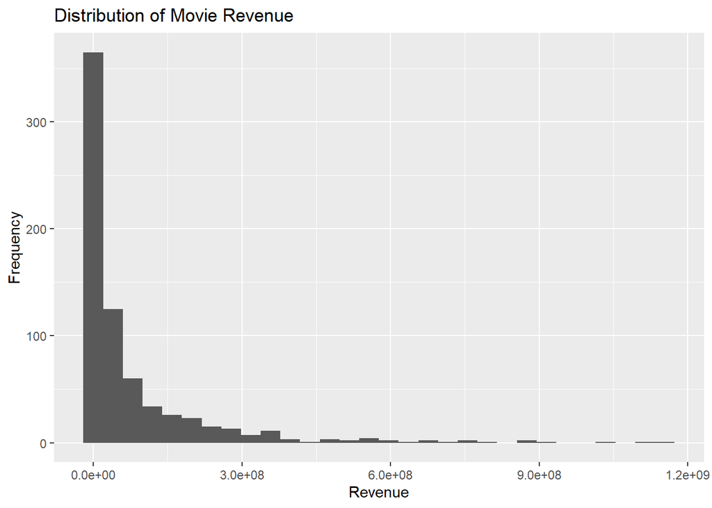

```r
#WRITE YOUR CODE HERE
ggplot(dataset, aes(x = revenue)) +
  geom_histogram() +
  labs(
    title = "Distribution of Movie Revenue",
    x = "Revenue",
    y = "Frequency"
  )
```

**Your Answer:**

The revenue distribution is skewed to the right. Most movies seem to have lower revenues, while only a small number of movies have extremely high revenues. This tells us that movies with extremely high movie revenues are concentrated among a relatively small number of movies.

*Step d*

```r
#WRITE YOUR CODE HERE
dataset = dataset %>%
  mutate(log_revenue = log(revenue))

zero_revenue = dataset %>%
  filter(revenue == 0) %>%
  select(revenue, log_revenue)

  head(zero_revenue)
```

|  | revenue | log_revenue |
| --- | --- | --- |
| 1 | 0 | -Inf |
| 2 | 0 | -Inf |
| 3 | 0 | -Inf |
| 4 | 0 | -Inf |
| 5 | 0 | -Inf |
| 6 | 0 | -Inf |

```r
average_log_revenue = mean(dataset$log_revenue, na.rm = TRUE)
print(average_log_revenue)
```

```
## [1] -Inf
```

**Your Answer:**

For movies with revenues equal to 0, the log revenue becomes -Inf. Because the log revenue variable contains these -Inf values, its mean also is -Inf.

*Step e*

```r
#WRITE YOUR CODE HERE
dataset = dataset %>%
  mutate(log_revenue = na_if(log_revenue, -Inf))

log_revenue_no_na = dataset$log_revenue[!is.na(dataset$log_revenue)]

mean(log_revenue_no_na)
```

```
## [1] 17.35027
```

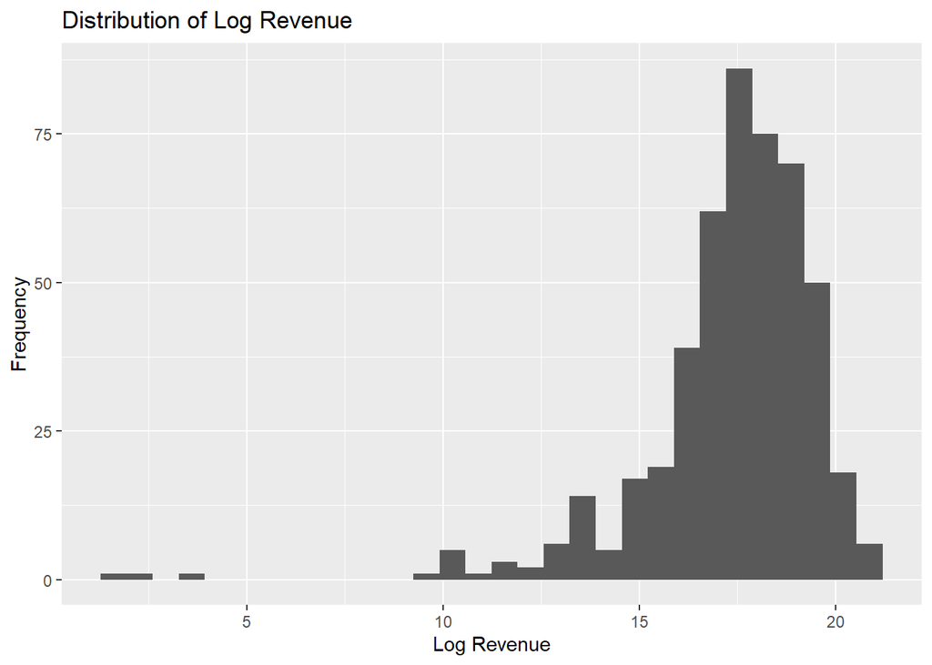

```r
ggplot(dataset, aes(x = log_revenue)) +
  geom_histogram() +
  labs(
    title = "Distribution of Log Revenue",
    x = "Log Revenue",
    y = "Frequency"
  )
```

**Your Answer:** Replacing the log revenues of zero-revenue movies with NA, the mean log revenue is around 17.35. The log transform reduces the strong right skewness of the original revenue variable. The distribution of log-revenue is left-skewed with a longer tail for the lower values.

*Step f*

```r
#WRITE YOUR CODE
dataset = dataset %>%
  mutate(log_revenue = na_if(log_revenue, -Inf))

revenue_mean = mean(dataset$revenue)
revenue_sd = sd(dataset$revenue)
revenue_n = nrow(dataset)

revenue_skewness =
  (1 / revenue_n) *
  sum(((dataset$revenue - revenue_mean) / revenue_sd)^3, na.rm = TRUE)

revenue_kurtosis =
  (1 / revenue_n) *
  sum(((dataset$revenue - revenue_mean) / revenue_sd)^4, na.rm = TRUE) - 3

print(revenue_skewness)
```

```
## [1] 3.545528
```

```r
print(revenue_kurtosis)
```

```
## [1] 15.69794
```

```r
log_revenue = dataset$log_revenue[!is.na(dataset$log_revenue)]

log_n = sum(!is.na(dataset$log_revenue))
log_mean = mean(log_revenue)
log_sd = sd(log_revenue)

log_skewness =
  (1 / log_n) *
  sum(((log_revenue - log_mean) / log_sd)^3)

log_kurtosis =
  (1 / log_n) *
  sum(((log_revenue - log_mean) / log_sd)^4) - 3

print(log_skewness)
```

```
## [1] -2.462296
```

```r
print(log_kurtosis)
```

```
## [1] 11.46588
```

**Your Answer:**

Revenue has a skewness of approximately 3.55, which matches the right skewed shape of the revenue histogram. Log revenue has a skewness of about -2.46 which matches the left skewed shape of the log revenue histogram. The excess kurtosis is about 15.70 for revenue and 11.47 for log revenue. Both values are much higher than 0, this means that both distributions are different from a normal distribution